# 190108-custom-example

This notebook uses custom functions to:

1. Load raw counts matrices (from indrops.py pipeline) for multiple libraries
2. Filter out background barcodes (i.e., free-floating RNA from otherwise empty droplets)
3. Filter out dead cells (high in mitochondrial genes)
4. Merge data from multiple libraries
5. Perform standard pre-processing:  
   a. Normalization  
   b. Highly variable gene filtering  
   c. Centering and variance scaling (z-score)  
   d. PCA  
   e. KNN graph construction  
   f. Louvain clustering g. UMAP (2-D embedding)  
   h. Doublet prediction
6. Export to SPRING plot for interactive data exploration

#### Dependencies

- This notebook uses Python 3 and a bunch of libraries. To install the necessary libraries (sorry if I missed any):

  ```
  conda install scipy numpy scikit-learn matplotlib pandas cython numba h5py
  conda install -c conda-forge umap-learn
  pip install python-igraph louvain
  ```

- Scrublet (for predicting doublets; optional)
  - See GitHub page for installation instructions:  
    https://github.com/AllonKleinLab/scrublet/
- SPRING (for interactive visualization)
  - Currently runs on Python 2; see GitHub page for required libraries:  
    https://github.com/AllonKleinLab/SPRING_dev

## Setup

#### Import libraries

```python
%matplotlib inline

import sys
import numpy as np
import scipy.sparse as ssp
import pandas as pd
import os
import matplotlib.pyplot as plt
import scrublet as scr

# !!!!
# Change this path to point to folder containing helper_functions.py
sys.path.append('./')
import helper_functions as hf
```

#### Set up display parameters for nicer looking plots

```python
plt.rcParams['font.family'] = 'sans-serif'
plt.rcParams['font.sans-serif'] = 'Arial'
plt.rc('font', size=12)
plt.rcParams['pdf.fonttype'] = 42
```

## Load raw data

#### Specify metadata and path to raw data

If you just want to quickly test this, include only one or two samples in the `sample_name` list below.

```python
# Directory containing raw data (counts matrices) from indrops.py pipeline
data_dir = 'data'

# List of samples/libraries to load
sample_name = ['d10_ctrl_1',
               'd10_ctrl_2',
               'd30_ctrl_1',
               'd30_ctrl_2',
               'm4_ctrl_1',
               'm4_ctrl_2',
              ]

meta_labels = ['timepoint', 'condition']
meta_info = {'d10_ctrl_1': ['day_10', 'ctrl'],
             'd10_ctrl_2': ['day_10', 'ctrl'],
             'd30_ctrl_1': ['day_10', 'ctrl'],
             'd30_ctrl_2': ['day_30', 'ctrl'],
             'm4_ctrl_1': ['day_120', 'ctrl'],
             'm4_ctrl_2': ['day_120', 'ctrl']}
```

#### Load counts matrices

```python
# D is a dictionary that will store data for each library (sample).
# Each entry (one per library) is another dictionary with the
# following keys (loosely based on AnnData scheme):
#   - E: raw counts matrix (scipy.sparse.csc_matrix, shape (n_cells, n_genes))
#   - obs: metadata for each cell (pandas dataframe, shape (n_cells, n_annotations))
#   - uns: for unstructured data/parameters (dictionary)

D = {}

#####
# Set some default filtering parameters. These can be
# customized for each library at a later step.

# min number of UMIs per cell barcode, for separating
# background from real cells
default_min_tot = 500

# max fraction of UMIs from mitochondrial genes, for
# separating live and dead cells
default_max_mito_frac = 0.15

####
# Loop over each library, adding data to D

for s in sample_name:
    # Initialize entry with default filtering parameters
    D[s] = {'uns': {'min_tot': default_min_tot, 'max_mt': default_max_mito_frac}}

    # Try loading counts matrix from .npz file (fast).
    # If .npz file doesn't exist yet, load from .tsv file
    # (the output of indrops.py pipeline) and save .npz
    # for future use.
    npz_file = f'{data_dir}/{s}.counts.npz'

    if os.path.exists(npz_file):
        # Load counts from .npz file, as well as cell barcode IDs and gene names
        Etmp = ssp.load_npz(npz_file)
        bctmp = np.loadtxt(f'{data_dir}/{s}.barcodes.txt', dtype=str)
        genetmp = np.loadtxt(f'{data_dir}/{s}.genes.txt', dtype=str)

    else:
        # Load counts matrix, cell barcode IDs, and gene names from indrops.py .tsv file
        Etmp, bctmp, genetmp = hf.load_annotated_text(hf.file_opener(f'{data_dir}/{s}.counts.tsv.gz'),
                                                      read_column_labels=True, read_row_labels=True)

        # Save counts matrix, cell barcode IDs, and gene names to files for future use.
        ssp.save_npz(npz_file, Etmp, compressed=True)
        np.savetxt(f'{data_dir}/{s}.barcodes.txt', bctmp, fmt='%s')
        np.savetxt(f'{data_dir}/{s}.genes.txt', genetmp, fmt='%s')

    # Store data in data dictionary
    D[s]['E'] = Etmp.copy()

    # Initialize obs dataframe with barcode IDs, library ID,
    # and any other pre-specified metadata from meta_labels
    D[s]['obs'] = pd.DataFrame({'barcode': bctmp})
    D[s]['obs']['library'] = s
    for iLab, lab in enumerate(meta_labels):
        D[s]['obs'][lab] = meta_info[s][iLab]

    # All libraries have same gene list, so just store as global variable
    gene_list = genetmp.copy()

    # Print info about what we loaded
    print('{:20} {} cell barcodes, {} genes'.format(s, *D[s]['E'].shape))

    # Clean up temporary variables
    del Etmp, bctmp, genetmp
```

```
d10_ctrl_1           3235 cell barcodes, 40523 genes
d10_ctrl_2           5181 cell barcodes, 40523 genes
d30_ctrl_1           3481 cell barcodes, 40523 genes
d30_ctrl_2           3058 cell barcodes, 40523 genes
m4_ctrl_1            4650 cell barcodes, 40523 genes
m4_ctrl_2            3922 cell barcodes, 40523 genes
```

## Filter out background based on UMIs/cell

#### First, plot histograms and customize filtering thresholds

No filtering is actually done here, just checking that the total UMIs threshold is appropriate for each library. The threshold should lie between the two modes of the histogram, where the left mode corresponds to background and the right to real cells. Also check that (roughly) the expected number of cells are passing the filter.

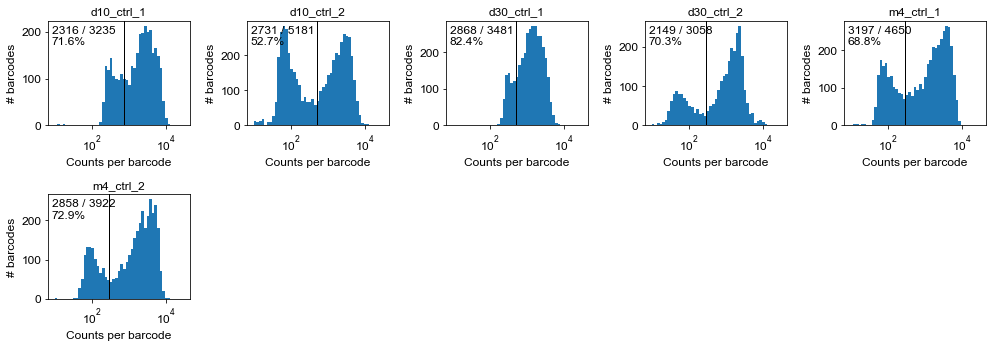

```python
# Change total count thresholds based on the histograms.
# If a library is not included below, the default threshold is used.
D['d10_ctrl_1']['uns']['min_tot'] = 750
D['d30_ctrl_2']['uns']['min_tot'] = 300
D['m4_ctrl_1']['uns']['min_tot'] = 300
D['m4_ctrl_2']['uns']['min_tot'] = 300

# Start figure
fig, nrow, ncol = hf.start_subplot_figure(len(sample_name), row_height=2.5)

for iS,s in enumerate(sample_name):
    # Loop over each library, plotting histogram of total counts (UMIs) per cell

    # Set subplot
    ax = plt.subplot(nrow, ncol, iS+1)

    # Calculate total counts per cells (row sums of counts matrix)
    D[s]['obs']['total_counts'] = D[s]['E'].sum(1).A.squeeze()

    # Get minimum total counts threshold. Barcodes with
    # total counts >= min_tot are considered real cells.
    min_tot = D[s]['uns']['min_tot']

    # Plot the histogram
    hf.total_counts_histogram(D[s]['obs']['total_counts'], min_bin=10, max_bin=3e4, ax=ax)
    ax.set_title(s, fontsize=12)

    xl = np.array(ax.get_xlim())
    yl = np.array(ax.get_ylim())
    ax.set_xlim(xl)
    ax.set_ylim(yl)

    # Plot the threshold
    ax.plot(min_tot * np.ones(2), yl, c='black', linewidth=1)

    # Calculate number of barcodes passing filter and show on plot
    ntot = len(D[s]['obs']['total_counts'])
    npass = (D[s]['obs']['total_counts'] >= min_tot).sum()
    ax.text(xl[0] + 10**(np.log10(xl.ptp())*0.05), yl[0] + yl.ptp() * 0.88, '{} / {}'.format(npass, ntot), fontsize=12)
    ax.text(xl[0] + 10**(np.log10(xl.ptp())*0.05), yl[0] + yl.ptp() * 0.77, '{:.1f}%'.format(npass/ntot*100), fontsize=12)

fig.tight_layout()
```

#### Now actually remove barcodes with too few UMIs

```python
print('{:20s}{:>25s}{:>25s}'.format('Sample', '# barcodes pre-filter', '# barcodes post-filter'))

for s in sample_name:
    keep = D[s]['obs']['total_counts'] >= D[s]['uns']['min_tot']
    D[s]['E'] = D[s]['E'][keep.values,:]
    D[s]['obs'] = D[s]['obs'][keep]

    n_orig = len(keep)
    n_pass = keep.sum()
    print('{:20s}{:>25}{:>25}'.format(s, n_orig, n_pass))
```

```
Sample                  # barcodes pre-filter   # barcodes post-filter
d10_ctrl_1                               3235                     2316
d10_ctrl_2                               5181                     2731
d30_ctrl_1                               3481                     2868
d30_ctrl_2                               3058                     2149
m4_ctrl_1                                4650                     3197
m4_ctrl_2                                3922                     2858
```

## Filter out dead cells based on mitochondrial gene fraction

#### Find mitochondrial genes (for mouse: all genes starting with "mt-")

```python
mt_ix = np.array([i for i,g in enumerate(gene_list) if g.startswith('mt-')], dtype=int)
print(gene_list[mt_ix])
```

```
['mt-Atp6' 'mt-Atp8' 'mt-Co1' 'mt-Co2' 'mt-Co3' 'mt-Cytb' 'mt-Nd1'
 'mt-Nd2' 'mt-Nd3' 'mt-Nd4' 'mt-Nd4l' 'mt-Nd5' 'mt-Nd6' 'mt-Rnr1'
 'mt-Rnr2' 'mt-Ta' 'mt-Tc' 'mt-Td' 'mt-Te' 'mt-Tf' 'mt-Tg' 'mt-Th' 'mt-Ti'
 'mt-Tk' 'mt-Tl1' 'mt-Tl2' 'mt-Tm' 'mt-Tn' 'mt-Tp' 'mt-Tq' 'mt-Tr'
 'mt-Ts1' 'mt-Ts2' 'mt-Tt' 'mt-Tv' 'mt-Tw' 'mt-Ty']
```

#### First, plot histograms and customize filtering thresholds

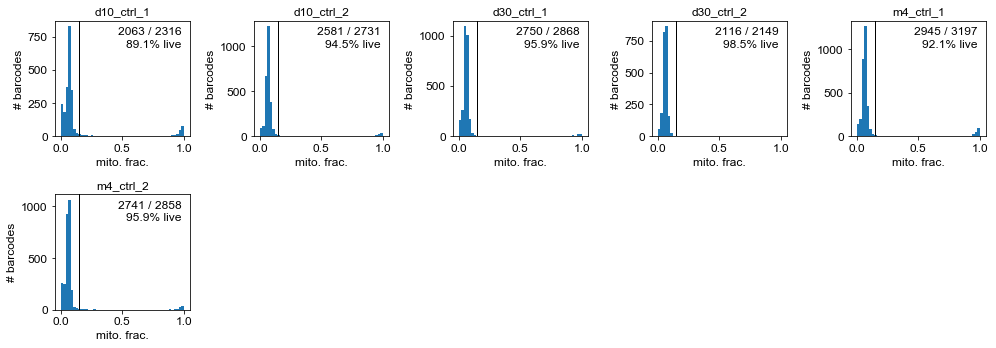

```python
# Adjust threshold if desired
# D['d10_ctrl_1']['uns']['max_mt'] = 0.25

# Start figure
fig, nrow, ncol = hf.start_subplot_figure(len(sample_name), row_height=2.5)

for iS,s in enumerate(sample_name):
    # Loop over each library, plotting histogram of fraction of UMIs
    # coming from mitochondrial genes.

    # Set subplot
    ax = plt.subplot(nrow, ncol, iS+1)

    # Calculate fraction of counts from mitochondrial  genes
    D[s]['obs']['mito_frac'] = D[s]['E'][:,mt_ix].sum(1).A.squeeze() / D[s]['E'].sum(1).A.squeeze()

    # Get maximum mitochondrial gene fraction. Barcodes with
    # mito fracs <= max_mt are considered live cells.
    max_mt = D[s]['uns']['max_mt']

    # Plot the histogram
    ax.hist(D[s]['obs']['mito_frac'], np.linspace(0, 1, 50));
    ax.set_title(s, fontsize=12)
    ax.set_xlabel('mito. frac.')
    ax.set_ylabel('# barcodes')

    xl = np.array([0,1])
    yl = np.array(ax.get_ylim())
    ax.set_ylim(xl)
    ax.set_ylim(yl)

    # Plot the threshold
    ax.plot(max_mt * np.ones(2), yl, c='black', linewidth=1)

    # Calculate number of barcodes passing filter and show on plot
    ntot = len(D[s]['obs']['mito_frac'])
    npass = (D[s]['obs']['mito_frac'] <= max_mt).sum()
    ax.text(xl[0] + xl.ptp()*0.98, yl[0] + yl.ptp() * 0.88, '{} / {}'.format(npass, ntot), fontsize=12, ha='right')
    ax.text(xl[0] + xl.ptp()*0.98, yl[0] + yl.ptp() * 0.77, '{:.1f}% live'.format(npass/ntot*100), fontsize=12, ha='right')

fig.tight_layout()
```

#### Now actually remove barcodes with too many mitochondrial gene counts

```python
print('{:20s}{:>25s}{:>25s}'.format('Sample', '# barcodes pre-filter', '# barcodes post-filter'))

for s in sample_name:
    keep = D[s]['obs']['mito_frac'] <= D[s]['uns']['max_mt']
    D[s]['E'] = D[s]['E'][keep.values,:]
    D[s]['obs'] = D[s]['obs'][keep]

    n_orig = len(keep)
    n_pass = keep.sum()
    print('{:20s}{:>25}{:>25}'.format(s, n_orig, n_pass))
```

```
Sample                  # barcodes pre-filter   # barcodes post-filter
d10_ctrl_1                               2316                     2063
d10_ctrl_2                               2731                     2581
d30_ctrl_1                               2868                     2750
d30_ctrl_2                               2149                     2116
m4_ctrl_1                                3197                     2945
m4_ctrl_2                                2858                     2741
```

## Merge filtered data from all libraries

Store data in dictionary `Dm`, which has similar structure to each item in `D`.

```python
Dm = {'uns': {}}
Dm['E'] = ssp.vstack([D[s]['E'] for s in sample_name]).tocsc()
Dm['obs'] = pd.concat([D[s]['obs'] for s in sample_name], ignore_index=True)
print(Dm['E'].shape)
```

```
(15196, 40523)
```

## Pre-process the merged data

#### Set pre-processing parameters

```python
# Gene filtering: keep genes with >=min_counts counts in >=min_cells cells
# and in the most variable min_vscore_pctl percentile of genes
min_counts = 3
min_cells = 3
min_vscore_pctl = 85

# Number of principal components
n_pcs = 50

# Number of neighbors for KNN graph construction
n_neighbors = 5

# UMAP parameters
umap_n_neighbors = 10
umap_min_dist = 0.3
```

#### Run pre-processing

```
Normalizing...
Finding highly variable genes...
```

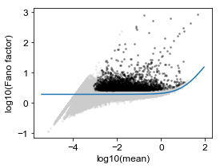

```
Using 2985 genes for PCA...
Getting kNN graph...
Running Louvain clustering...
Running UMAP...
Done!
```

```python
# Total counts normalization to help remove
# technical variation between cells
print('Normalizing...')
Dm['E_norm'] = hf.tot_counts_norm(Dm['E'])[0]

# Identify highly variable genes
print('Finding highly variable genes...')
Dm['uns']['gene_filter'] = hf.filter_genes(Dm['E_norm'],
                                           min_counts=min_counts,
                                           min_cells=min_cells,
                                           min_vscore_pctl=min_vscore_pctl,
                                           show_vscore_plot=True)

# Run PCA on cells using highly variable genes.
# hf.get_pca automatically scales the data (z-score)
# at the gene level before running PCA.
print('Using {} genes for PCA...'.format(len(Dm['uns']['gene_filter'])))
Dm['pca'] = hf.get_pca(Dm['E_norm'][:, Dm['uns']['gene_filter']],
                       numpc=n_pcs)

# Build k-nearest neighbor graph
print('Getting kNN graph...')
Dm['uns']['knn_edges'] = hf.get_knn_graph(Dm['pca'], k=n_neighbors, return_edges=True)[0]

# Cluster cells (Louvain clustering)
print('Running Louvain clustering...')
Dm['obs']['louvain'] = hf.get_louvain_clusters(Dm['E'].shape[0], Dm['uns']['knn_edges'], resolution=1.0)

# Get 2-D embedding using UMAP
print('Running UMAP...')
Dm['umap'] = hf.get_umap(Dm['pca'],
                         min_dist=umap_min_dist,
                         n_neighbors=umap_n_neighbors
                        )

print('Done!')
```

## Visualize using 2-D embedding (UMAP)

```python
x = Dm['umap'][:,0]
y = Dm['umap'][:,1]
```

#### Check out where each sample's cells lie in the embedding

In each subplot, cells from one sample are colored black, and all others are gray.  
Because this example notebook only includes control cells, they should mostly overlap.

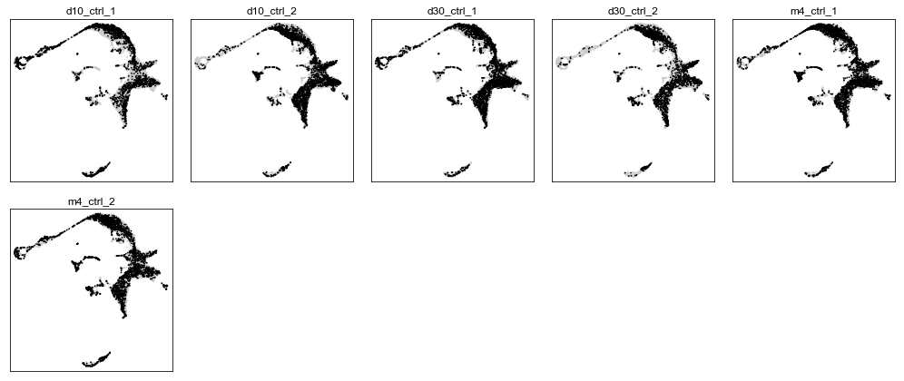

```python
hf.plot_groups(x, y, Dm['obs']['library'].values.astype(str))
```

#### Color by Louvain clustering

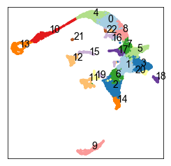

```python
hf.plot_categorical(x, y, Dm['obs']['louvain'].values, show_centroids=True, centroid_label_size=14)
```

#### Color by expression of marker genes

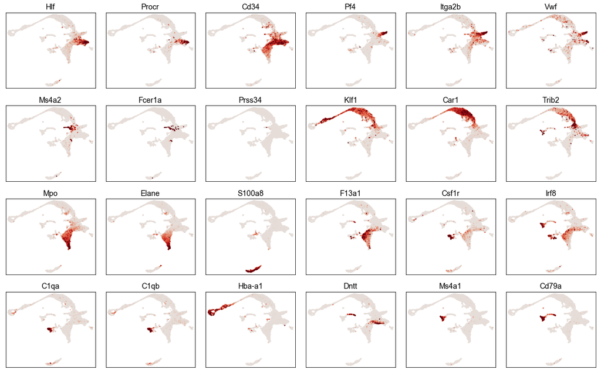

```python
# List of genes to plot
genes_plot = ['Hlf', 'Procr', 'Cd34', # stem/progenitor
              'Pf4', 'Itga2b', 'Vwf', # megakaryocyte
              'Ms4a2', 'Fcer1a', 'Prss34', # basophil/mast cell
              'Klf1', 'Car1','Trib2', # erythroid progenitor
              'Mpo', 'Elane', 'S100a8', # neutrophil
              'F13a1', 'Csf1r', 'Irf8', # monocyte/macrophage
              'C1qa', 'C1qb', 'Hba-a1', # mature macrophage/erythroblastic island
              'Dntt', 'Ms4a1', 'Cd79a' # lymphoid
             ]


# Start figure
fig,nrow,ncol = hf.start_subplot_figure(len(genes_plot), row_height=2.5, n_columns=6, fig_width=16)

# Plot each gene's expression in a different subplot
for iG,g in enumerate(genes_plot):
    ax = plt.subplot(nrow, ncol, iG+1)
    hf.plot_one_gene(Dm['E_norm'], gene_list, g, x, y, ax=ax, col_range=(0, 99.8), point_size=1)
    ax.set_title(g)

fig.tight_layout()
```

## Run Scrublet to predict cell doublets

#### Run with automatic threshold detection

```python
scrub = scr.Scrublet(Dm['E'], expected_doublet_rate=0.06)
Dm['obs']['doublet_score'], Dm['obs']['predicted_doublets'] = scrub.scrub_doublets(n_prin_comps=50)
```

```
Preprocessing...
Simulating doublets...
Embedding transcriptomes using PCA...
Calculating doublet scores...
Automatically set threshold at doublet score = 0.42
Detected doublet rate = 1.7%
Estimated detectable doublet fraction = 27.8%
Overall doublet rate:
	Expected   = 6.0%
	Estimated  = 6.1%
Elapsed time: 20.4 seconds
```

#### Check that threshold is reasonable and adjust if necessary

Threshold should lie between the two peaks for the "Simulated doublets" histogram.  
Run the following to adjust threshold (e.g., to 0.3), if necessary:

```
Dm['obs']['predicted_doublets'] = scrub.call_doublets(threshold=0.3)
```

```
Detected doublet rate = 2.2%
Estimated detectable doublet fraction = 34.5%
Overall doublet rate:
	Expected   = 6.0%
	Estimated  = 6.4%
```

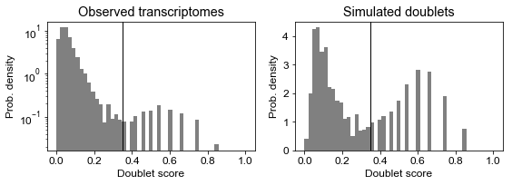

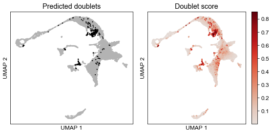

```python
Dm['obs']['predicted_doublets'] = scrub.call_doublets(threshold=0.35)

scrub.plot_histogram();
scrub.set_embedding('UMAP', Dm['umap']);
scrub.plot_embedding('UMAP', order_points=True);
```

## Export data for SPRING exploration

```python
# Specify directory for saving the SPRING data; this should be
# a subdirectory of the SPRING code repository downloaded from GitHub.
spring_main='/Users/sam/Dropbox (HMS)/inDrops_Analysis/SPRING-latest/classifier/SPRING_dev/datasets/example/'

# Save the main data files
print('writing hdf5 files')
hf.write_spring_main(spring_main, Dm['E_norm'], gene_list, Dm['obs']['total_counts'].values)

# Save the SPRING subplot (one particular version of preprocessing
# and 2-D embedding)
print('writing subplot files')
hf.write_spring_subplot(f'{spring_main}/full', Dm['E_norm'], gene_list, np.arange(Dm['E'].shape[0]), Dm['umap'],
                        Dm['uns']['knn_edges'], Dm['obs']['total_counts'].values, Dm['pca'], Dm['uns']['gene_filter'],
                        obs_df=Dm['obs'],
                        categ_vars=['louvain', 'library', 'timepoint', 'condition', 'predicted_doublets'],
                        contin_vars=['mito_frac', 'doublet_score']
                       )
```

```
writing hdf5 files
```

```
writing subplot files
```

After export, the SPRING plot can be viewed by following these steps:

1. Open the Terminal and `cd` to the SPRING directory. In the example above:

   ```
   cd "/Users/sam/Dropbox (HMS)/inDrops_Analysis/SPRING-latest/classifier/SPRING_dev/"
   ```

2. Activate a Python 2 environment that includes SPRING's required libaries:

   ```
   source activate spring
   ```

3. Start a local server

   ```
   python -m CGIHTTPServer 8000
   ```

4. Open your internet browswer (SPRING works best in Chrome) and go to this URL:  
   http://localhost:8000/springViewer_1_6_dev.html?datasets/example/full